# BMIN503 Final Project: Thyroid Cancer — Penn Medicine Experience

Jacqueline Soegaard, MD

### Overview

My initial project goals were to evaluate the patterns of thyroid nodule management at Penn Medicine. My main faculty mentor from this project was Dr. Heather Wachtel from Endocrine Surgery. After discussing with her, I better understand the clinical context of health system management of thyroid nodules, particularly concerns for overdiagnosis and overmanagement. I also spoke with Yulia Borovskiy from the Penn Data Access Center to better understand the ways in which users/clinicians can request data from the Penn Data Access center for research purposes. We identified that we would need IRB review or a QI IRB exemption to obtain the data request and are in the process of submitting the request. Given their timelines, we determined that the process of obtaining IRB review and then having our data request completed by the DAC would take too long for the timeline of this class project. In discussing this challenge with Dr. Wachtel, she and Abigail Doucette (one of the PSOM senior data analysts) were able to give me access to an existing database of deidentified patient and tumor data for patients who received treatment for thyroid cancer within our health system.

Given that the initial goals of this project cannot be met with the existing database, I nevertheless believe we can gain new insights from this data regarding the characteristics of thyroid cancer patients and tumors at Penn Medicine. Specifically, we will look at summary demographics and statistics for this population and their tumors to compare with established numbers in the literature. Moreover, we can evaluate parameters for location and timing of evaluation and treatment, and identify characteristics associated with tumor upstaging, tumor recurrence, and death. Further, familiarity with this data—which contains similar variables to those we expect for our thyroid nodule management dataset—will be useful in defining the variable library and analysis code for the future project.

[Jacqueline Soegaard Final Project GitHub Repository](https://github.com/jsoegaard/BMIN503_Final_Project)

### Introduction

The thyroid gland is a butterfly-shaped endocrine gland located in the anterior neck. It secretes thyroid hormones— triiodothyronine (T3) and thyroxine (T4)— as well as calcitonin, which regulate various metabolic functions and regulate calcium homeostasis respectively. Thyroid cancer, which arises from cells in the thyroid gland, is a relatively uncommon cancer, with an estimated incidence of 52,890 cases per year in the United States ( [American Cancer Society: Cancer Statistics 2020](https://acsjournals.onlinelibrary.wiley.com/doi/full/10.3322/caac.21590) ). It carries a favorable prognosis, with a disease-related 5-year survival of 98% overall and of 56% in patients with distant metastatic disease at the time of diagnosis.

Thyroid cancer can be divided into several pathologic subtypes. The epithelial subtypes comprise three main categories: papillary (85% of cases), follicular (12%), and anaplastic or undifferentiated cancer (<3%). Medullary thyroid cancer (MTC) is another, rare malignancy—a neuroendocrine tumor arising from the parafollicular or C cells of the thyroid glands. It only accounts for 1-2 percent of thryoid cancers in the Unites States [Revised American Thyroid Association guidelines for the management of medullary thyroid carcinoma]. While most cases are sporadic, around 25% of cases are familial as part of the multiple endocrine neoplasia type 2 (MEN2) syndrome. Management includes total thyroidectomy and cervical lymph node dissection.

While thyroid malignancies are relatively rare, at Penn Medicine is a busy thyroid cancer referral center with extensive experience and tumor registry data for patients with this disease. The thyroid cancer patient population is managed by endocrinology, endocrine surgery, radiation oncology, at times medical oncology, and at times medical genetics; therefore, the multimodal management of these patients is by definition interdisciplinary. Given our local experience, we wish to examine our dataset to understand summary statistics for our local thyroid cancer population and their tumors and identify characteristics associated with outcomes of interest, in particular tumor upstaging on final pathologic evaluation, tumor recurrence, and death.

### Methods

#### Data Source:

`Extent of MTC dataset` obtained from Penn Medicine disease registries:

#### General Methodological Approach:

- Data cleaning
  - Join `patient` and `tumor` data into a single data frame.
  - Remove unnecessary columns
  - Convert variable data types into integer, numeric, factor, and date types as appropriate
  - Set clinical and pathologic staging variables (TNM and Overall staging variables) as factors with equivalent levels for each stage to enable comparison
  - Collapse factors with multiple low-frequency levels
- Create binary outcome variables
  - Upstaging - compare clinical and pathologic values for T (tumor status), N (nodal status), and Complete Stage. M (metastasis) stage not included since it typically is not affected by pathologic assessment.
  - Recurrence (based on variable `FirstRecurrenceDate`)
  - Death (based on `DeathDate`)
- Obtain summary statistics in tabular form
- Perform multivariate logistic regression to identify variables associated with the above outcomes
- Add plots to illustrate as appropriate

#### Code

First, load all necessary packages:

```r
knitr::opts_chunk$set(warning = FALSE, message = FALSE)

#Data manipulation packages
library(tidyverse)
library(stringr) #for string manipulation
library(dplyr)   #for data wrangling
library(forcats) #for factor variable manipulation

#Table package
library(table1) # for summary statistic tables

#Plotting and color pallete packages
library(ggplot2)
library(ggsci)

#Create general theme for plots
mytheme <- theme(plot.title = element_text(family = "Helvetica", face = "bold", size = (15), hjust = 0.5),
             legend.title = element_text(colour = "steelblue",  face = "bold.italic", family = "Helvetica"),
             legend.text = element_text(face = "italic", colour="steelblue4",family = "Helvetica"),
              axis.title = element_text(face = "bold", family = "Helvetica", size = (10), colour = "steelblue4"),
              axis.text = element_text(family = "Courier", colour = "steelblue4", size = (10)))
```

Next, load the dataset into a two dataframe - one called `patients` and another called `tumors`. The tumor dataset is larger because some patients had multiple tumors. All missing/empty values will be set to NA

```r
patients <- read.csv("~/Documents/LocalFiles/503_MTC_FinalProject/20232020_ThyroidCancer_RegistryData_2011to2018_Patients_deidentified.csv", na.strings=c("","NA"))
tumors.sep <- read.csv("~/Documents/LocalFiles/503_MTC_FinalProject/20232020_ThyroidCancer_RegistryData_2011to2018_Tumors_deidentified.csv", na.strings=c("","NA"))
```

Clean the data to facilitate manipulation and analysis. This will require joining the two datasets, removing unecessary variables, turning variables into factors or data elements as appropriate, and cleaning up factors that have many levels with low frequencies (and long level names) for ease of data analysis.

```r
#Merge the two datasets based on Patient id - add the patient data to the rows of 'tumors'
tumors <- tumors.sep %>% left_join(patients, by = "PatientSystemId") #add the patient-level data to the appropriate columns in the tumors file, by PatientSystemID
tumors$index <- seq(from=1, to=nrow(tumors), by=1) #for use with creating outcome variables
tumors$PathN[tumors$PathN=="c0"] <- "p0" #eliminate the c0 notation from the pathologic staging

#Remove uneccessary columns (which have the same value for all entries in dataset)
tumors3 <- tumors %>%
  select(-c(AnalyticYn, PrimarySiteCode, PrimarySiteDesc, PrimarySiteCategory, PrimarySiteSubcategory.x, PrimarySiteSubcategory.y, HUP_YN, PAH_YN, MCP_YN, PPMC_YN, CCH_YN, LGH_YN))

#Convert specific columns into factors
factor_cols <- c("ReportingHospital",
                 "PrimarySequence",
                 "ClassCaseDesc",
                 "HistologyCode",
                 "HistologyDesc",
                 "Laterality",
                 "Grade",
                 "ClinM",
                 "PathM",
                 "SurgeryDesc",
                 "RtDesc",
                 "RtModalityDesc",
                 "RtVolumeDesc",
                 "ChemoDesc",
                 "HormoneDesc",
                 "FirstRecurrenceType",
                 "Sex",
                 "Race",
                 "VitalStatus")

tumors3[,factor_cols] <- lapply(tumors3[,factor_cols], factor)

#For the staging variables, manually change into factors with sequence in such a way that the two are comparable (i.e. level 3 corresponds to stage 1A in both clinical and pathologic staging).

## We will not do this for the M variable since pathologic analysis does not typically change the M variable for thyroid cancer.

#Tumor Staging
tumors3$ClinT <- factor(tumors3$ClinT, levels = c("c0","c1","c1A","c1B","c2","c3","c4A","c4B","cX","88"))
tumors3$PathT <- factor(tumors3$PathT, levels = c("p0","p1","p1A","p1B","p2","p3","p4A","p4B", "pX","88"))

#Nodal Staging
tumors3$ClinN <- factor(tumors3$ClinN, levels = c("c0", "c1", "c1A", "c1B",  "cX", "88"))
tumors3$PathN <- factor(tumors3$PathN, levels = c("p0","p1","p1A", "p1B","pX", "88"))

#Overall Staging
tumors3$ClinStage <- factor(tumors3$ClinStage, levels = c("1", "2", "3", "4A", "4B", "4C", "N/A", "Unknown"))
tumors3$PathStage <- factor(tumors3$PathStage, levels = c("1", "2", "3", "4A", "4B", "4C", "N/A", "Unknown"))
tumors3$SummaryStage <- factor(tumors3$SummaryStage, levels = c("1", "2", "3", "4A", "4B", "4C", "88", "99"))

#Lymphovascular Invasion - rename the labels
tumors3$LvInvasion <- factor(tumors3$LvInvasion, levels = c("Lymph-vascular Invasion Present/Identified", "Lymph-vascular Invasion stated as Not Present","Unknown/Indeterminate/not mentioned in path report"), labels = c("LVI.Present", "LVI.Not.Present", "LVI.Unknown"))

#Convert date columns from character to date object
date_cols <- c("DateFirstContact.x",
               "DateDx.x",
               "MstDefSurgeryDate",
               "MstDefRtDate",
               "MstDefChemoDate",
               "MstDefHormoneDate",
               "MstDefImmunoDate",
               "FirstRecurrenceDate",
               "DateFirstContact.y",
               "DateDx.y",
               "LastContactDate",
               "DeathDate")
tumors3[,date_cols] <- lapply(tumors3[,date_cols], function(x) as.Date(x, "%m/%d/%Y"))

####Clean up factor variables

#Collapse less frequent histologies into "other"
tumors3$HistologyDesc <- fct_lump_n(tumors3$HistologyDesc, n=6)

#Collapse race categories
tumors3$Race <- fct_collapse(tumors3$Race, White = c("White"), Black = c("Black" , "Black or African American"), American.Indian = c("American Indian or Alaska Native", "American Indian, Aleutian, or Eskimo", "Native Hawaiian or Other Pacific Islander"), Asian.AsianIndian = c("Asian", "Asian Indian ", "Asian Indian or Pakistani, NOS", "Chinese", "Filipino", "Japanese", "Kampuchean (Cambodian)", "Other Asian, including Asian, NOS and Oriental, NO", "Pakistani" ), Other.Unknown = c("Multiple Races", "Other", "Other/Unknown", "Unknown"))

#Collapse surgeries
tumors3$SurgeryDesc <- fct_collapse(tumors3$SurgeryDesc, Total.Thyroidectomy = c("Total thyroidectomy"), Less.Than.Total.Thyroidectomy = c("Isthmectomy ONLY", "Lobectomy and/or isthmectomy", "Lobectomy ONLY", "Lobectomy WITH isthmus", "Local tumor destruction, NOS", "Subtotal or near total thyroidectomy","Removal of a lobe and partial removal of the contralateral lobe", "Removal of less than a lobe, Local surgical excision", "Removal of less than a lobe, NOS", "Removal of less than a lobe, Removal of a partial lobe ONLY"), No.Surgery = c("None; no surgery of primary site"), Unknown.Surgery = c("Unknown if surgery performed","Surgery, NOS", "Thyroidectomy, NOS"))

#Collapse treatment course sequence
tumors3$FirstCourseSummary <-fct_lump_min(tumors3$FirstCourseSummary, min=10) #group all sequences with fewer than 10 patients into "Other" category

#Collapse recurrence type
tumors3$FirstRecurrenceType <- fct_collapse(tumors3$FirstRecurrenceType, No.Recurrence = c("Patient became disease-free after treatment and has not had a recurrence; leukemia in remission."), Never.Disease.Free = c("Since diagnosis, patient has never been disease-free. This includes cases with distant metastasis at diagnosis, systemic disease, unknown primary, or minimal disease that is not treated."), Locoregional.Recurrence = c("Local recurrence and there is insufficient information available to code to 13-17. Recurrence is confined to the remnant of the organ of origin; to the organ of origin","Local recurrence of an invasive tumor.", "Recurrence of an in situ tumor in adjacent tissue or organ(s) and in regional lymph nodes at the same time.",  "Recurrence of an invasive tumor in adjacent tissue or organ(s) and in regional lymph nodes (both 21 and 22) at the same time.", "Recurrence of an invasive tumor in adjacent tissue or organ(s) only.", "Recurrence of an invasive tumor in regional lymph nodes only.", "Regional recurrence, and there is insufficient information available to code to 21-27.", "Both regional recurrence of an invasive tumor in adjacent tissue or organ(s) and/or regional lymph nodes (20-25) and local and/or trocar recurrence (10, 13, 14, or 15)."), Distant.Recurrence = c("Distant recurrence and there is insufficient information available to code to 46-62.", "Distant recurrence of an invasive tumor in a single distant site (51-58) and local, trocar, and/or regional recurrence (10-15, 20-25, or 30).", "Distant recurrence of an invasive tumor in bone only. This includes bones other than the primary site.", "Distant recurrence of an invasive tumor in lymph node only. Refer to the staging scheme for a description of lymph nodes that are distant for a particular site.", "Distant recurrence of an invasive tumor in multiple sites (recurrences that can be coded to more than one category 51-59).", "Distant recurrence of an invasive tumor in the lung only. Lung includes the visceral pleura.","Distant recurrence of an invasive tumor in the peritoneum only. Peritoneum includes peritoneal surfaces of all structures within the abdominal cavity and/or positive ascitic fluid.","Distant recurrence of an invasive tumor in the skin only. This includes skin other than the primary site.", "Distant systemic recurrence of an invasive tumor only. This includes leukemia, bone marrow metastasis, carcinomatosis, and generalized disease."), Recurrence.NOS  = c("Disease has recurred, but the type of recurrence is unknown."), Recurrence.Unknown = c( "It is unknown whether the disease has recurred or if the patient was ever disease-free." ))

#Create lag time variables
tumors3$surgLagTime <- as.numeric(tumors3$MstDefSurgeryDate) - as.numeric(tumors3$DateDx.x)
tumors3$surgLagTime_2 <- as.numeric(tumors3$MstDefSurgeryDate) - as.numeric(tumors3$DateFirstContact.x)
tumors3$rtLagTime <- as.numeric(tumors3$MstDefRtDate) - as.numeric(tumors3$MstDefSurgeryDate)
```

Now, we will create several outcome variables to study. These will include: patients with a diagnosis of medullary thyroid cancer, patients who recurred, patients who had upstaging on pathologic analysis of tumor samples, and patients who died. First, we must extract these patients.

```r
#Upstaging - extract cases with know clinical and pathologic staging (ie. stage not set to unknown/X/NA/88), then look at cases where upstaging occured (i.e. where pathologic evaluation rated a higher stage level than clinical staging)

#T Staging
t.staged <- tumors3 %>% filter(ClinT != "88") %>%
  filter(ClinT != "cX") %>%
  filter(ClinT != "NA") %>%
  filter(PathT != "88") %>%
  filter(PathT != "pX") %>%
  filter(PathT != "NA") %>%
  filter((as.numeric(PathT) - as.numeric(ClinT)) > 0)

#N Staging
nodes.staged <- tumors3 %>% filter(ClinN != "88") %>%
  filter(ClinN != "cX") %>%
  filter(ClinN != "NA") %>%
  filter(PathN != "88") %>%
  filter(PathN != "pX") %>%
  filter(PathN != "NA") %>%
  filter((as.numeric(PathN) - as.numeric(ClinN)) > 0)

#Complete Staging
tumors.staged <- tumors %>%
  filter(ClinStage != "Unknown") %>%
  filter(ClinStage != "NA") %>%
  filter(PathStage != "Unknown") %>%
  filter(PathStage != "NA") %>%
 filter((as.numeric(PathStage) - as.numeric(ClinStage)) > 0)


#Create variables for upstaging
blank.vector <- seq(from=0, to=0, length.out= nrow(tumors3))
tumors3$t.upstaged = blank.vector
tumors3$t.upstaged[t.staged$index] <- 1
tumors3$n.upstaged = blank.vector
tumors3$n.upstaged[nodes.staged$index] <- 1
tumors3$complete.upstaged = blank.vector
tumors3$complete.upstaged[tumors.staged$index]<- 1

#Add MTC, death, and recurrence outcome variables to dataset
tumors3 <- tumors3 %>%
  mutate(mtc = if_else(HistologyDesc == "Medullary Carcinoma, NOS", 1, 0)) %>%  # patients with MTC
  mutate(death = if_else(!is.na(DeathDate),1,0)) %>%  #extract patients dataset who have died
  mutate(recurred = if_else(!is.na(FirstRecurrenceDate),1,0)) #extract patients from dataset who have recurred

#Turn all the outcome variables into factors

tumors3$mtc <- factor(tumors3$mtc, levels = c(0,1), labels = c("other histology", "mtc"))
tumors3$death <- factor(tumors3$death, levels = c(0,1), labels = c("alive", "death"))
tumors3$recurred <- factor(tumors3$recurred, levels = c(0,1), labels = c("no recurrence", "recurrence"))
tumors3$t.upstaged <-  factor(tumors3$t.upstaged, levels = c(0,1), labels = c("no.t.upstaging", "t.upstaged"))
tumors3$n.upstaged <-  factor(tumors3$n.upstaged, levels = c(0,1), labels = c("no.n.upstaging", "n.upstaged"))
tumors3$complete.upstaged <-  factor(tumors3$complete.upstaged, levels = c(0,1), labels = c("no.complete.upstaging", "complete.upstaged"))

#Column names of resulting dataset fields
colnames(tumors3)
```

```
##  [1] "TumorId"             "PatientSystemId"     "ReportingHospital"   "PrimarySequence"     "ClassCaseDesc"       "DateFirstContact.x"  "DateDx.x"            "AgeAtDx.x"           "HistologyCode"       "HistologyDesc"       "Laterality"          "Grade"               "LvInvasion"          "ClinT…
## [19] "PathN"               "PathM"               "PathStage"           "SummaryStage"        "FirstCourseSummary"  "MstDefSurgeryDate"   "SurgeryDesc"         "MstDefRtDate"        "RtDesc"              "RtDoseCgy"           "RtBoostDoseCgy"      "RtModalityDesc"      "RtVolumeDesc"        "MstDe…
## [37] "ImmunoDesc"          "FirstRecurrenceDate" "FirstRecurrenceType" "Sex"                 "Race"                "DateFirstContact.y"  "DateDx.y"            "AgeAtDx.y"           "LastContactDate"     "VitalStatus"         "DeathDate"           "index"               "surgLagTime"         "surgL…
## [55] "mtc"                 "death"               "recurred"
```

### Results

First, we will include a table of descriptive statistics for our Penn Medicine thyroid cancer population.

#### Table of Descriptive Statistics

```r
table1::label(tumors3$AgeAtDx.x) <- "Age at Diagnosis"
table1::label(tumors3$Sex) <- "Sex"
table1::label(tumors3$Race) <- "Race"
table1::label(tumors3$ReportingHospital) <- "Reporting Hospital"
table1::label(tumors3$HistologyDesc) <- "Histologic diagnosis"
table1::label(tumors3$ClinStage) <- "Clinical Stage - Overall"
table1::label(tumors3$PathStage) <- "Pathologic Stage - Overall"
table1::label(tumors3$SurgeryDesc) <- "Surgery"
table1::label(tumors3$RtDesc) <- "Radiation Therapy"
table1::label(tumors3$HormoneDesc) <- "Hormone Therapy"
table1::label(tumors3$ChemoDesc) <- "Chemotherapy"
table1::label(tumors3$t.upstaged) <- "Primary Tumor Upstaging"
table1::label(tumors3$n.upstaged) <- "Nodal Upstaging"
table1::label(tumors3$complete.upstaged) <- "Overall Upstaging"
table1::label(tumors3$recurred) <- "Recurred"
table1::label(tumors3$FirstRecurrenceType) <- "First Recurrence Type"
table1::label(tumors3$death) <- "Death"

tumors_summarytable <- table1::table1(~AgeAtDx.x + Sex + Race + ReportingHospital + HistologyDesc + ClinStage + PathStage + SurgeryDesc + RtDesc + t.upstaged + n.upstaged + complete.upstaged + recurred + FirstRecurrenceType + death, data = tumors3)

tumors_summarytable
```

|  | Overall (N=5351) |
| --- | --- |
| Age at Diagnosis |  |
| Mean (SD) | 50.6 (15.4) |
| Median [Min, Max] | 51.0 [14.0, 100] |
| Sex |  |
| F | 3940 (73.6%) |
| M | 1411 (26.4%) |
| Race |  |
| American.Indian | 11 (0.2%) |
| Asian.AsianIndian | 269 (5.0%) |
| Black | 571 (10.7%) |
| Other.Unknown | 344 (6.4%) |
| White | 4156 (77.7%) |
| Reporting Hospital |  |
| CCH | 324 (6.1%) |
| HUP | 3530 (66.0%) |
| LGH | 530 (9.9%) |
| MCP | 503 (9.4%) |
| PAH | 354 (6.6%) |
| PPMC | 110 (2.1%) |
| Histologic diagnosis |  |
| Carcinoma, Undifferentiated, NOS | 36 (0.7%) |
| Follicular Adenocarcinoma, NOS | 186 (3.5%) |
| Medullary Carcinoma, NOS | 86 (1.6%) |
| Oxyphilic Adenocarcinoma | 103 (1.9%) |
| Papillary & Follicular Adenocarcinoma | 2346 (43.8%) |
| Papillary Adenocarcinoma, NOS | 2545 (47.6%) |
| Other | 49 (0.9%) |
| Clinical Stage - Overall |  |
| 1 | 2612 (48.8%) |
| 2 | 486 (9.1%) |

[output cut: 52 more lines]

The data above reveal that our Penn Medicine population has a median age of 51, which matches those reported in the literature. Furthermore, our population is predominantly female (73.6%), which again is consistent with the fact that thyroid cancer is more common in women. Racial distribution demonstrated that it was most common in caucasian patients (77.7%) followed by black patients (10.7%). The majority of thyroid cancer cases were reported from the Hospital of the University of Pennsylvania (HUP, 66%), with the remainder of cases distributed among the other Penn Medicine Hospitals.

Regarding treatment modalities, almost all patients had either a total thyroidectomy (81%) or a less than total thyroidectomy (15.7%). This later category includes surgeries such as subtotal thyroidectomy, thyroid lobectomy (left or right), or isthmusectomy. The majority of patients (55%) did not require radiation treatment; however, 32.7% did receive radioactive iodine therapy for treatment of their thyroid cancer. Few patients received other modalities of radiation therapy, chemotherapy, or immunotherapy (these are generally very uncommon treatment modalities for thyroid cancer).

Finally, four our outcomes of interest:

- **Tumor upstaging:** when looking at tumor stage, 16.8% of tumors were upstaged (i.e. moved to a higher stage between clinical and pathologic staging)
- **Nodal upstaging:** when looking at nodal stage, 11.9% of tumors were upstaged on pathologic evaluation
- **Overall upstaging:** 4.6% of patients moved to a higher overall stage after pathologic analysis
- **Recurrence:** 2.6% of tumors recurred (of these, the most common recurrence type was locoregional recurrence in 1.9% of patients while 0.7% of patients had distant recurrence)
- **Death:** 2.7% of patients from the dataset had deaths recorded (note, we do not have specific information as to the length of follow-up or information as to wether these were disease-specific mortalities or all-cause mortalities)

#### Plots of Descriptive Statistics

We will next include some plots to understand the age distribution of our thyroid cancer patients, the distribution of histologies in our population, and the distribution of clinical and pathologic stages.

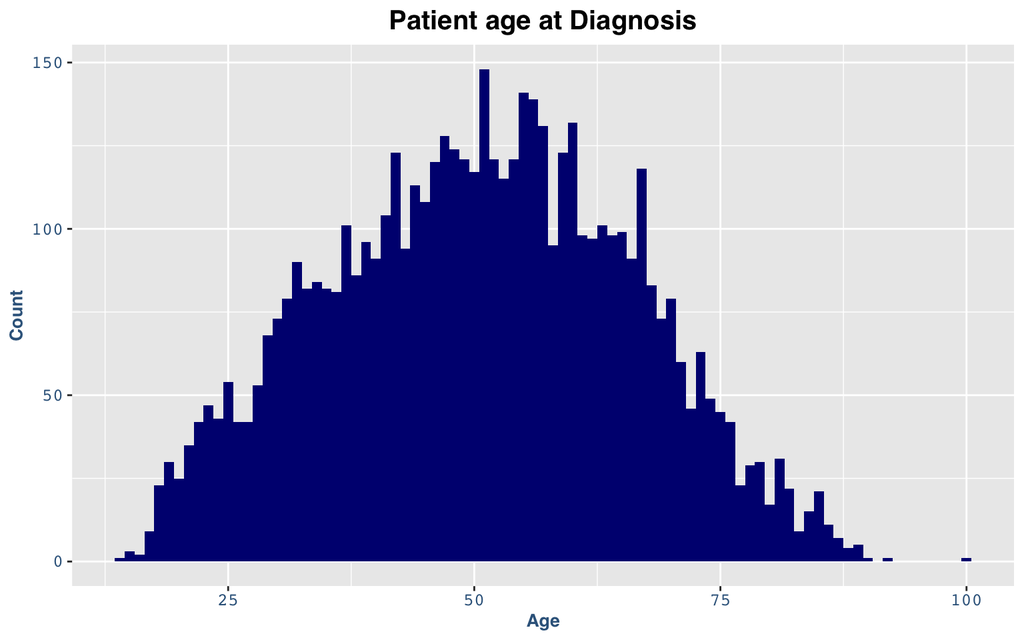

```r
#make a histogram of the ages in the dataset
ggplot() + geom_histogram(data=tumors3, aes(AgeAtDx.x), binwidth = 1, fill="navy") +
      ggtitle("Patient age at Diagnosis") +
      mytheme + labs(y= "Count", x="Age")
```

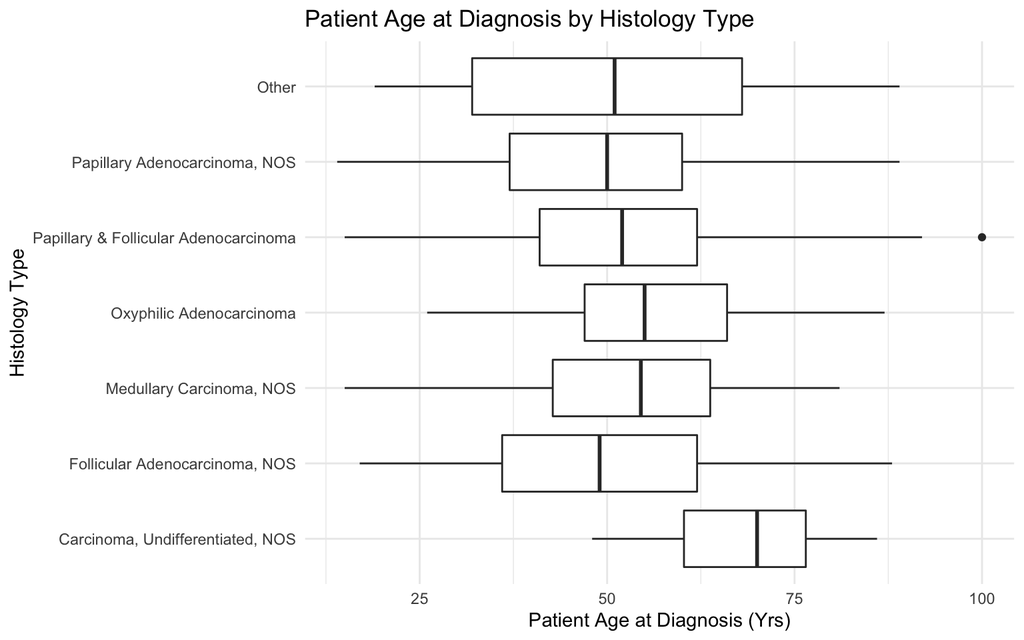

```r
ggplot(data = tumors3, aes(x = AgeAtDx.x, y = factor(HistologyDesc))) +
      geom_boxplot() +
      ggtitle("Patient Age at Diagnosis by Histology Type") +
      mytheme + labs(y= "Histology Type", x="Patient Age at Diagnosis (Yrs)") + theme_minimal()
```

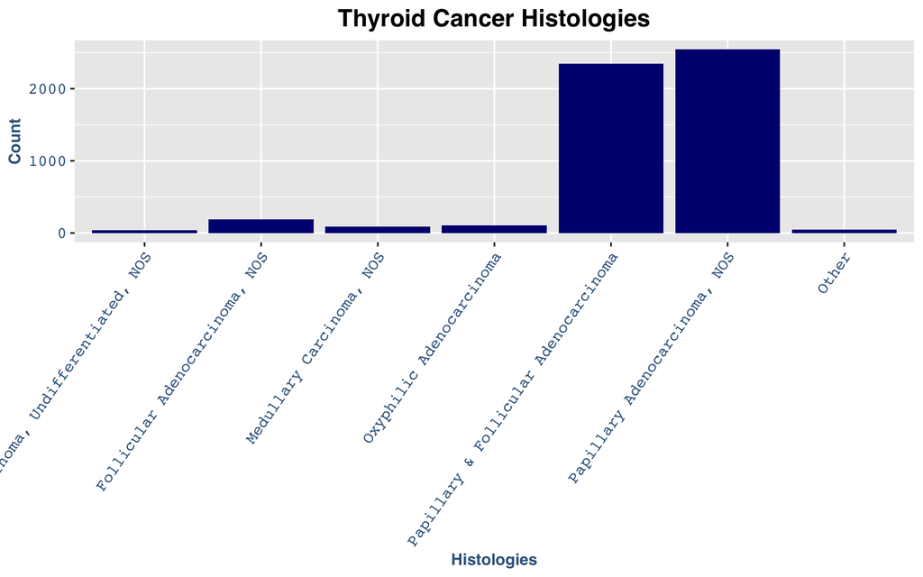

```r
#Bar plot comparing histologies
ggplot(data = tumors3, aes(x = HistologyDesc)) +
      geom_bar(fill="navy") +
      ggtitle("Thyroid Cancer Histologies") +
      mytheme + labs(y= "Count", x="Histologies") +
      theme(axis.text.x = element_text(angle = 55,hjust=1))
```

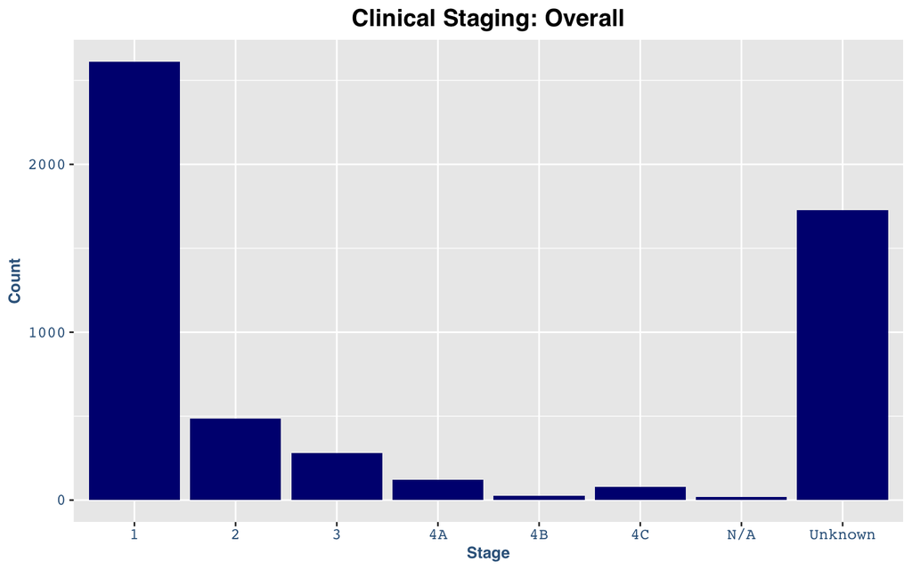

```r
#Bar plot comparing clinical and pathologic stages
ggplot(data = tumors3, aes(x = ClinStage)) +
      geom_bar(fill="navy") +
      ggtitle("Clinical Staging: Overall") +
      mytheme + labs(y= "Count", x="Stage")
```

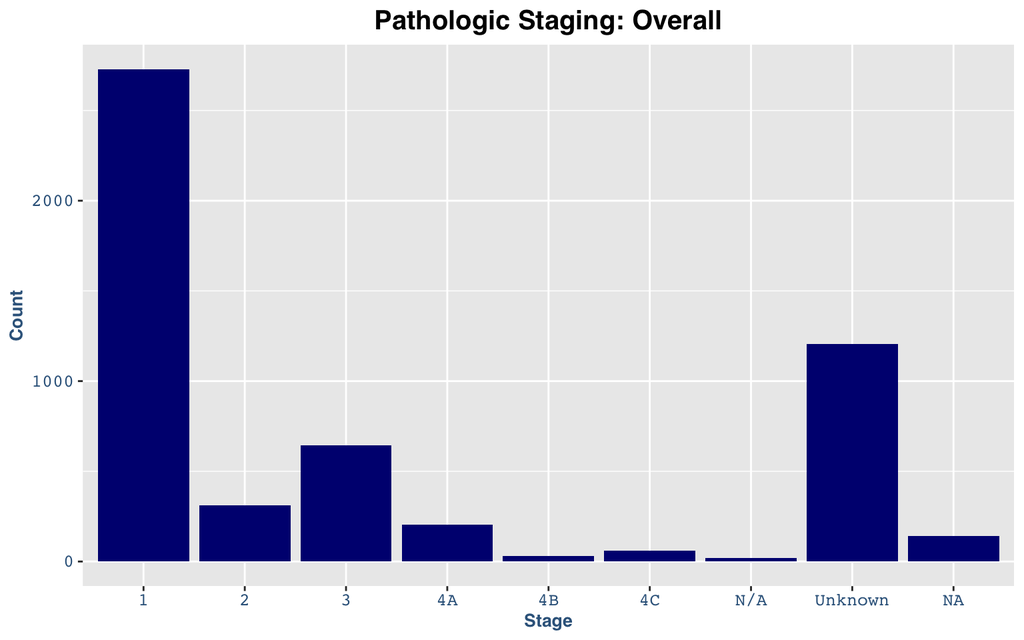

```r
ggplot(data = tumors3, aes(x = PathStage)) +
      geom_bar(fill="navy") +
      ggtitle("Pathologic Staging: Overall") +
      mytheme + labs(y= "Count", x="Stage")
```

From these plots we note that the age distribution of the patient population spans almost the entire lifespan with a medial of 51 years. Also, most histologic subtypes have median ages that cluster around the early 50s except for anaplastic or undiferrentiated thyroid cancer, a very aggressive subtype which has a higher median age.

#### Regression Analyses

We will perform multivariate regression analyses to study associations between a subset of the variables and different outcomes of interest. For each model I chose to include the most salient and interpretable variables that are characteristics of the patient or tumor itself and not of a posteriori treatment decisions. (Statistical significance is defined as p < 0.05.

```r
#Factors associated with mtc histology

    #Multivariate logistic regression analysis for mtc histology (binary outcome) - commented out since will not be discussing further in results
    mtc.fit <- glm(mtc ~ AgeAtDx.x + Sex + Race + LvInvasion + ClinStage + PathStage + recurred + death + t.upstaged + n.upstaged, data=tumors3, family = binomial())
    summary(mtc.fit)
```

```
##
## Call:
## glm(formula = mtc ~ AgeAtDx.x + Sex + Race + LvInvasion + ClinStage +
##     PathStage + recurred + death + t.upstaged + n.upstaged, family = binomial(),
##     data = tumors3)
##
## Deviance Residuals:
##     Min       1Q   Median       3Q      Max
## -0.7843  -0.1769  -0.1428  -0.1288   3.2269
##
## Coefficients: (1 not defined because of singularities)
##                             Estimate Std. Error z value Pr(>|z|)
## (Intercept)               -16.259667 692.919721  -0.023  0.98128
## AgeAtDx.x                  -0.006652   0.009055  -0.735  0.46257
## SexM                        0.400376   0.239482   1.672  0.09456 .
## RaceAsian.AsianIndian      11.803830 692.919987   0.017  0.98641
## RaceBlack                  12.716808 692.919696   0.018  0.98536
## RaceOther.Unknown          12.199018 692.919801   0.018  0.98595
## RaceWhite                  12.508271 692.919627   0.018  0.98560
## LvInvasionLVI.Not.Present  -0.721263   0.270289  -2.668  0.00762 **
## LvInvasionLVI.Unknown      -0.827741   0.422880  -1.957  0.05030 .
## ClinStage2                 -0.050400   0.467852  -0.108  0.91421
## ClinStage3                 -0.538595   0.667806  -0.807  0.41995
## ClinStage4A                 1.084552   0.628568   1.725  0.08445 .
## ClinStage4B                 1.326060   1.051072   1.262  0.20708
## ClinStage4C                -0.220092   1.431112  -0.154  0.87777
## ClinStageN/A              -11.764421 535.216493  -0.022  0.98246
## ClinStageUnknown            0.142518   0.319229   0.446  0.65528
## PathStage2                  1.324638   0.439631   3.013  0.00259 **
## PathStage3                  0.409882   0.422223   0.971  0.33166
## PathStage4A                 0.529624   0.588622   0.900  0.36824
## PathStage4B                 0.946006   1.029162   0.919  0.35799
## PathStage4C                 1.333828   1.435072   0.929  0.35266
## PathStageN/A                      NA         NA      NA       NA
## PathStageUnknown            0.128454   0.362078   0.355  0.72276
## recurredrecurrence          1.011842   0.387426   2.612  0.00901 **
## deathdeath                  0.194680   0.541084   0.360  0.71900
## t.upstagedt.upstaged       -0.129276   0.329634  -0.392  0.69492
## n.upstagedn.upstaged        0.014773   0.351886   0.042  0.96651
## ---
## Signif. codes:  0 '***' 0.001 '**' 0.01 '*' 0.05 '.' 0.1 ' ' 1
##
## (Dispersion parameter for binomial family taken to be 1)
##
##     Null deviance: 859.83  on 5202  degrees of freedom
## Residual deviance: 795.71  on 5177  degrees of freedom
##   (148 observations deleted due to missingness)
## AIC: 847.71
##
## Number of Fisher Scoring iterations: 15
```

```r
    #Recurred fit
    recurred.fit <- glm(recurred ~ AgeAtDx.x + Sex + Race + LvInvasion + HistologyDesc + ClinStage + PathStage + t.upstaged + n.upstaged, data=tumors3, family = binomial())
    summary(recurred.fit)
```

```
##
## Call:
## glm(formula = recurred ~ AgeAtDx.x + Sex + Race + LvInvasion +
##     HistologyDesc + ClinStage + PathStage + t.upstaged + n.upstaged,
##     family = binomial(), data = tumors3)
##
## Deviance Residuals:
##     Min       1Q   Median       3Q      Max
## -1.3697  -0.2213  -0.1659  -0.1305   3.1718
##
## Coefficients: (1 not defined because of singularities)
##                                                      Estimate Std. Error z value Pr(>|z|)
## (Intercept)                                        -1.883e+01  1.760e+03  -0.011  0.99146
## AgeAtDx.x                                          -1.354e-02  7.454e-03  -1.816  0.06932 .
## SexM                                                3.513e-01  1.910e-01   1.839  0.06586 .
## RaceAsian.AsianIndian                               1.428e+01  1.760e+03   0.008  0.99352
## RaceBlack                                           1.534e+01  1.760e+03   0.009  0.99305
## RaceOther.Unknown                                   1.357e+01  1.760e+03   0.008  0.99385
## RaceWhite                                           1.518e+01  1.760e+03   0.009  0.99312
## LvInvasionLVI.Not.Present                          -1.145e+00  2.050e-01  -5.585 2.34e-08 ***
## LvInvasionLVI.Unknown                              -1.013e+00  3.450e-01  -2.936  0.00333 **
## HistologyDescFollicular Adenocarcinoma, NOS        -1.416e+01  4.646e+02  -0.030  0.97568
## HistologyDescMedullary Carcinoma, NOS               1.512e+00  1.172e+00   1.290  0.19718
## HistologyDescOxyphilic Adenocarcinoma               9.758e-01  1.256e+00   0.777  0.43727
## HistologyDescPapillary & Follicular Adenocarcinoma  4.113e-01  1.147e+00   0.358  0.72003
## HistologyDescPapillary Adenocarcinoma, NOS          8.382e-01  1.144e+00   0.733  0.46377
## HistologyDescOther                                  1.509e+00  1.262e+00   1.196  0.23181
## ClinStage2                                          5.520e-01  3.754e-01   1.470  0.14143
## ClinStage3                                          9.925e-01  3.551e-01   2.795  0.00519 **
## ClinStage4A                                         1.158e+00  4.620e-01   2.507  0.01218 *
## ClinStage4B                                         1.482e+00  9.405e-01   1.576  0.11510
## ClinStage4C                                        -8.367e-01  1.415e+00  -0.591  0.55442
## ClinStageN/A                                       -1.354e+01  1.446e+03  -0.009  0.99253
## ClinStageUnknown                                    4.345e-01  2.701e-01   1.609  0.10762
## PathStage2                                         -7.031e-02  5.368e-01  -0.131  0.89579
## PathStage3                                          6.547e-01  3.038e-01   2.155  0.03115 *
## PathStage4A                                         1.256e+00  4.018e-01   3.125  0.00178 **
## PathStage4B                                         6.942e-01  8.906e-01   0.779  0.43572
## PathStage4C                                         1.215e+00  1.411e+00   0.861  0.38909
## PathStageN/A                                               NA         NA      NA       NA
## PathStageUnknown                                    2.989e-01  3.071e-01   0.973  0.33037
## t.upstagedt.upstaged                                4.920e-01  2.269e-01   2.168  0.03012 *
## n.upstagedn.upstaged                                2.443e-01  2.391e-01   1.021  0.30709
## ---
## Signif. codes:  0 '***' 0.001 '**' 0.01 '*' 0.05 '.' 0.1 ' ' 1
##
## (Dispersion parameter for binomial family taken to be 1)
##
##     Null deviance: 1281.3  on 5202  degrees of freedom
## Residual deviance: 1085.9  on 5173  degrees of freedom
##   (148 observations deleted due to missingness)
## AIC: 1145.9
##
## Number of Fisher Scoring iterations: 17
```

```r
    #Death fit
   death.fit <- glm(death ~ AgeAtDx.x + Sex + Race + LvInvasion + HistologyDesc + ClinStage + PathStage + recurred + t.upstaged + n.upstaged, data=tumors3, family = binomial())
    summary(death.fit)
```

```
##
## Call:
## glm(formula = death ~ AgeAtDx.x + Sex + Race + LvInvasion + HistologyDesc +
##     ClinStage + PathStage + recurred + t.upstaged + n.upstaged,
##     family = binomial(), data = tumors3)
##
## Deviance Residuals:
##     Min       1Q   Median       3Q      Max
## -2.2361  -0.2067  -0.1369  -0.0898   3.4912
##
## Coefficients: (1 not defined because of singularities)
##                                                      Estimate Std. Error z value Pr(>|z|)
## (Intercept)                                        -18.825123 665.768111  -0.028  0.97744
## AgeAtDx.x                                            0.068676   0.007834   8.766  < 2e-16 ***
## SexM                                                 0.300127   0.203303   1.476  0.13988
## RaceAsian.AsianIndian                               12.585840 665.767898   0.019  0.98492
## RaceBlack                                           12.912109 665.767774   0.019  0.98453
## RaceOther.Unknown                                   12.690699 665.767817   0.019  0.98479
## RaceWhite                                           12.071463 665.767739   0.018  0.98553
## LvInvasionLVI.Not.Present                           -0.259555   0.264486  -0.981  0.32642
## LvInvasionLVI.Unknown                                0.103144   0.313730   0.329  0.74233
## HistologyDescFollicular Adenocarcinoma, NOS         -1.368052   0.672587  -2.034  0.04195 *
## HistologyDescMedullary Carcinoma, NOS               -0.942411   0.667083  -1.413  0.15773
## HistologyDescOxyphilic Adenocarcinoma               -1.573545   0.797920  -1.972  0.04860 *
## HistologyDescPapillary & Follicular Adenocarcinoma  -1.543856   0.508457  -3.036  0.00239 **
## HistologyDescPapillary Adenocarcinoma, NOS          -1.475996   0.499489  -2.955  0.00313 **
## HistologyDescOther                                   0.198233   0.649354   0.305  0.76015
## ClinStage2                                           0.351228   0.387832   0.906  0.36514
## ClinStage3                                           0.515284   0.431964   1.193  0.23291
## ClinStage4A                                          1.348137   0.517093   2.607  0.00913 **
## ClinStage4B                                          2.824161   0.688674   4.101 4.12e-05 ***
## ClinStage4C                                          2.382852   0.606878   3.926 8.62e-05 ***
## ClinStageN/A                                       -12.222875 503.124012  -0.024  0.98062
## ClinStageUnknown                                     0.232698   0.288517   0.807  0.41994
## PathStage2                                          -0.241238   0.475124  -0.508  0.61164
## PathStage3                                          -0.158961   0.354306  -0.449  0.65368
## PathStage4A                                         -0.394563   0.501135  -0.787  0.43108
## PathStage4B                                          0.285501   0.656865   0.435  0.66382
## PathStage4C                                         -0.194692   0.649097  -0.300  0.76422
## PathStageN/A                                               NA         NA      NA       NA
## PathStageUnknown                                    -0.255115   0.291715  -0.875  0.38183
## recurredrecurrence                                   0.460227   0.421270   1.092  0.27462
## t.upstagedt.upstaged                                 0.093995   0.293000   0.321  0.74836
## n.upstagedn.upstaged                                 0.529757   0.323868   1.636  0.10190
## ---
## Signif. codes:  0 '***' 0.001 '**' 0.01 '*' 0.05 '.' 0.1 ' ' 1
##
## (Dispersion parameter for binomial family taken to be 1)
##
##     Null deviance: 1331.29  on 5202  degrees of freedom
## Residual deviance:  946.43  on 5172  degrees of freedom
##   (148 observations deleted due to missingness)
## AIC: 1008.4
##
## Number of Fisher Scoring iterations: 15
```

```r
    #Nodal Upstaging Fit
    n.upstaging.fit <- glm(n.upstaged ~ AgeAtDx.x + Sex + Race + LvInvasion + HistologyDesc + mtc + t.upstaged, data=tumors3, family = binomial())
    summary(n.upstaging.fit)
```

```
##
## Call:
## glm(formula = n.upstaged ~ AgeAtDx.x + Sex + Race + LvInvasion +
##     HistologyDesc + mtc + t.upstaged, family = binomial(), data = tumors3)
##
## Deviance Residuals:
##     Min       1Q   Median       3Q      Max
## -1.7220  -0.4874  -0.3553  -0.2490   3.0770
##
## Coefficients: (1 not defined because of singularities)
##                                                      Estimate Std. Error z value Pr(>|z|)
## (Intercept)                                         -0.601736   1.350862  -0.445  0.65600
## AgeAtDx.x                                           -0.029549   0.003079  -9.596  < 2e-16 ***
## SexM                                                 0.266296   0.102747   2.592  0.00955 **
## RaceAsian.AsianIndian                                0.352346   1.118407   0.315  0.75273
## RaceBlack                                           -0.159993   1.116889  -0.143  0.88609
## RaceOther.Unknown                                    0.355278   1.115349   0.319  0.75008
## RaceWhite                                            0.554301   1.102123   0.503  0.61501
## LvInvasionLVI.Not.Present                           -1.356605   0.101084 -13.421  < 2e-16 ***
## LvInvasionLVI.Unknown                               -1.867126   0.199620  -9.353  < 2e-16 ***
## HistologyDescFollicular Adenocarcinoma, NOS        -15.261807 271.078953  -0.056  0.95510
## HistologyDescMedullary Carcinoma, NOS                0.179568   0.830382   0.216  0.82880
## HistologyDescOxyphilic Adenocarcinoma               -2.343450   1.263377  -1.855  0.06361 .
## HistologyDescPapillary & Follicular Adenocarcinoma   0.032226   0.766790   0.042  0.96648
## HistologyDescPapillary Adenocarcinoma, NOS           0.544613   0.765369   0.712  0.47673
## HistologyDescOther                                   0.531193   0.879768   0.604  0.54599
## mtcmtc                                                     NA         NA      NA       NA
## t.upstagedt.upstaged                                 1.111740   0.098859  11.246  < 2e-16 ***
## ---
## Signif. codes:  0 '***' 0.001 '**' 0.01 '*' 0.05 '.' 0.1 ' ' 1
##
## (Dispersion parameter for binomial family taken to be 1)
##
##     Null deviance: 3893.1  on 5345  degrees of freedom
## Residual deviance: 3280.3  on 5330  degrees of freedom
##   (5 observations deleted due to missingness)
## AIC: 3312.3
##
## Number of Fisher Scoring iterations: 16
```

```r
    #Tumor Upstaging Fit
    t.upstaging.fit <- glm(t.upstaged ~ AgeAtDx.x + Sex + Race + LvInvasion + HistologyDesc + mtc + n.upstaged, data=tumors3, family = binomial())
    summary(t.upstaging.fit)
```

```
##
## Call:
## glm(formula = t.upstaged ~ AgeAtDx.x + Sex + Race + LvInvasion +
##     HistologyDesc + mtc + n.upstaged, family = binomial(), data = tumors3)
##
## Deviance Residuals:
##     Min       1Q   Median       3Q      Max
## -1.1842  -0.5681  -0.5527  -0.4851   2.5931
##
## Coefficients: (1 not defined because of singularities)
##                                                      Estimate Std. Error z value Pr(>|z|)
## (Intercept)                                        -15.779633 238.846779  -0.066    0.947
## AgeAtDx.x                                           -0.002132   0.002522  -0.845    0.398
## SexM                                                 0.032358   0.086200   0.375    0.707
## RaceAsian.AsianIndian                                0.895855   1.072915   0.835    0.404
## RaceBlack                                            0.555188   1.069049   0.519    0.604
## RaceOther.Unknown                                    0.844447   1.071317   0.788    0.431
## RaceWhite                                            0.674437   1.062678   0.635    0.526
## LvInvasionLVI.Not.Present                           -0.407110   0.097299  -4.184 2.86e-05 ***
## LvInvasionLVI.Unknown                               -0.643922   0.154888  -4.157 3.22e-05 ***
## HistologyDescFollicular Adenocarcinoma, NOS         12.419802 238.844638   0.052    0.959
## HistologyDescMedullary Carcinoma, NOS               13.628133 238.844548   0.057    0.954
## HistologyDescOxyphilic Adenocarcinoma               12.702845 238.844733   0.053    0.958
## HistologyDescPapillary & Follicular Adenocarcinoma  13.836230 238.844371   0.058    0.954
## HistologyDescPapillary Adenocarcinoma, NOS          13.825652 238.844370   0.058    0.954
## HistologyDescOther                                  13.083196 238.844848   0.055    0.956
## mtcmtc                                                     NA         NA      NA       NA
## n.upstagedn.upstaged                                 1.092975   0.098785  11.064  < 2e-16 ***
## ---
## Signif. codes:  0 '***' 0.001 '**' 0.01 '*' 0.05 '.' 0.1 ' ' 1
##
## (Dispersion parameter for binomial family taken to be 1)
##
##     Null deviance: 4843.1  on 5345  degrees of freedom
## Residual deviance: 4593.3  on 5330  degrees of freedom
##   (5 observations deleted due to missingness)
## AIC: 4625.3
##
## Number of Fisher Scoring iterations: 14
```

```r
    #Complete upstaging fit -  commented out since will not be discussing further in results (the tumor and nodal upstaging was more interesting/specific)
    #complete.upstaging.fit <- glm(complete.upstaged ~ AgeAtDx.x + Sex + Race + LvInvasion + HistologyDesc + mtc + recurred + death, data=tumors3, family = binomial())
    #summary(complete.upstaging.fit)
```

Based on the above information, we will further delve into the variables found to be significantly associated with the following outcomes: * tumor upstaging * nodal upstaging * recurrence * death

**Tumor upstaging sub-analyses:** first, we find that tumor upstaging is negatively correlated with the absence of lymphovascular invasion (LVI) (p 2.86e-05) and positively associated with concurrent nodal upstaging (p < 2e-16). Note that “lymphovascular invasion present”is a pathologic determination that means there is tumor invading into adjacent blood and lymphatic vessels; this is typically a sign of a more aggressive tumor because it denotes the tumor’s ability to spread via hematogenous or lymphatic routes.

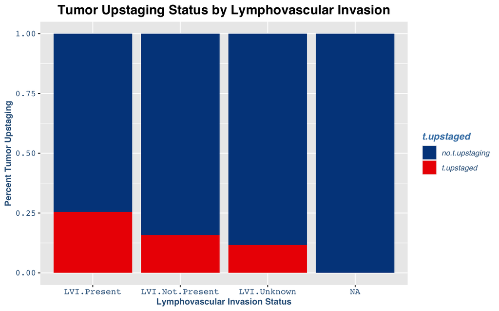

```r
    # Tumor upstaging status (binary) as a function of Lymphovascular Invasion (categorical), with bar plot
    t.upstaged.LVI.plot <- ggplot(data = tumors3, aes(x = factor(LvInvasion), fill = t.upstaged)) +
      geom_bar(position = "fill") +
      ggtitle("Tumor Upstaging Status by Lymphovascular Invasion") +
      mytheme + labs(y= "Percent Tumor Upstaging", x="Lymphovascular Invasion Status") +
      scale_fill_lancet()

    # Tumor upstaging status (binary) as a function of nodal upstaging (categorical), with bar plot
    t.upstaged.nupstaged.plot <- ggplot(data = tumors3, aes(x = factor(n.upstaged), fill = t.upstaged)) + geom_bar(position = "fill") +
      ggtitle("Tumor Upstaging Status by Nodal Upstaging") +
      mytheme + labs(y= "Percent Tumor Upstaging", x="Nodal Upstaging Status") +
      scale_fill_lancet()

    #Render the plots
    t.upstaged.LVI.plot
```

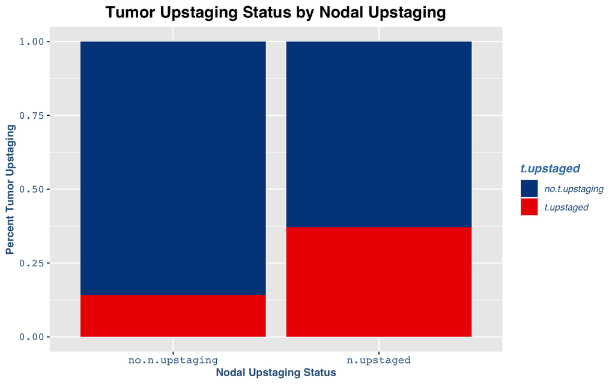

```r
    t.upstaged.nupstaged.plot
```

**Nodal upstaging sub-analyses:** We noted in the results of the logistic regression above that nodal upstaging was negatively associated with older age at diagnosis (p <2e-16) and negatively associated with the absence of LVI (p <2e-16) but positively associated with male gender (p = 0.00955) and with concurrent tumor upstaging (p<2e-16).

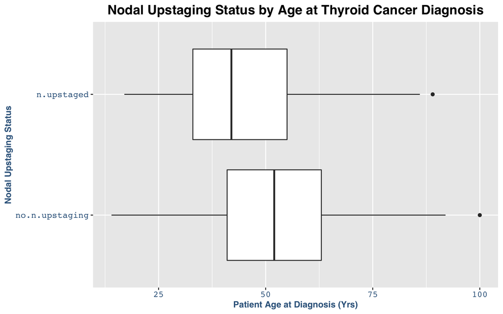

```r
    # Nodal upstaging status (binary) as a function of patient age at diagnosis (continuous), with box plot

    n.upstaged.age.plot <- ggplot(data = tumors3, aes(x = AgeAtDx.x, y = n.upstaged)) +
      geom_boxplot() +
      ggtitle("Nodal Upstaging Status by Age at Thyroid Cancer Diagnosis") +
      mytheme + labs(y= "Nodal Upstaging Status", x="Patient Age at Diagnosis (Yrs)")

    # Nodal upstaging status (binary) as a function of sex (binary), with bar plot
    n.upstaged.sex.plot <- ggplot(data = tumors3, aes(x = factor(Sex), fill = n.upstaged)) +
      geom_bar(position = "fill") +
      ggtitle("Nodal Upstaging Status by Gender") +
      mytheme + labs(y= "Percent Nodal Upstaging", x="Gender") +
      scale_fill_lancet()

    # Nodal upstaging status (binary) as a function of Lymphovascular Invasion (categorical), with bar plot
    n.upstaged.LVI.plot <- ggplot(data = tumors3, aes(x = factor(LvInvasion), fill = n.upstaged)) +
      geom_bar(position = "fill") +
      ggtitle("Nodal Upstaging Status by Lymphovascular Invasion") +
      mytheme + labs(y= "Percent Nodal Upstaging", x="Lymphovascular Invasion Status") +
      scale_fill_lancet()

    # Nodal upstaging status (binary) as a function of tumor upstaging (binary), with bar plot
    n.upstaged.t.upstaged.plot <- ggplot(data = tumors3, aes(x = factor(t.upstaged), fill = n.upstaged)) +
      geom_bar(position = "fill") +
      ggtitle("Nodal Upstaging Status by Tumor Upstaging Status") +
      mytheme + labs(y= "Percent Nodal Upstaging", x="Tumor Upstaging Status") +
      scale_fill_lancet()

    #Render the plots
    n.upstaged.age.plot
```

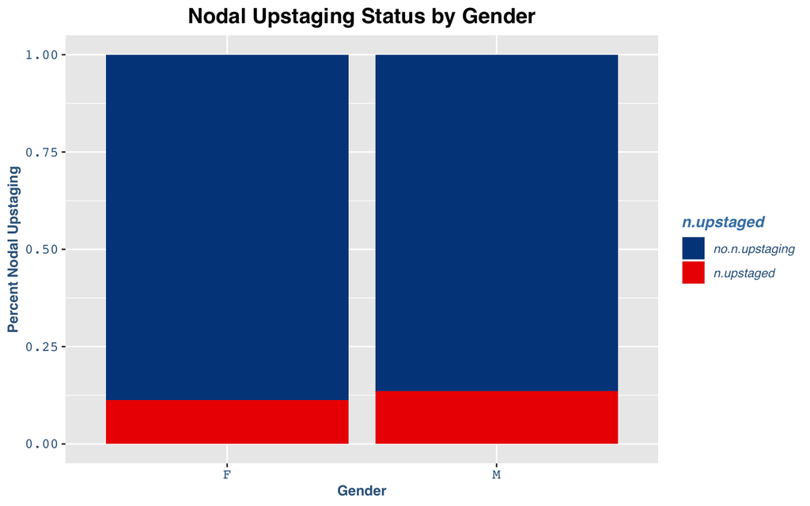

```r
    n.upstaged.sex.plot
```

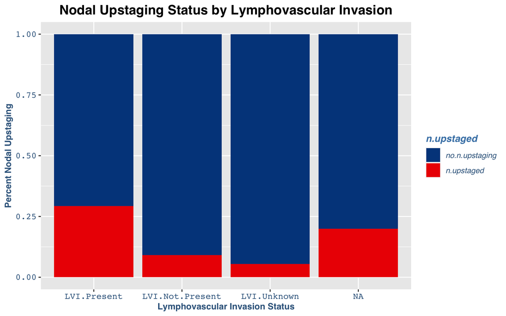

```r
    n.upstaged.LVI.plot
```

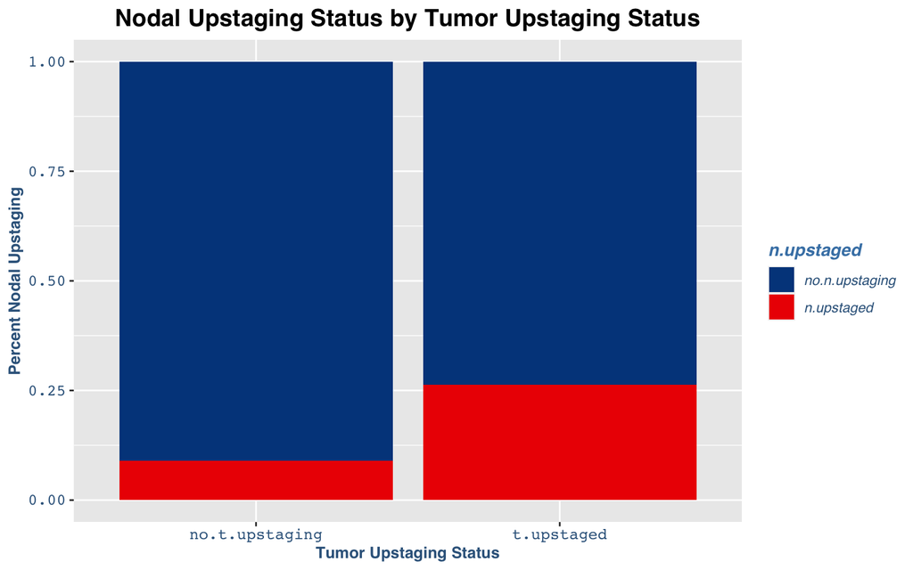

```r
    n.upstaged.t.upstaged.plot
```

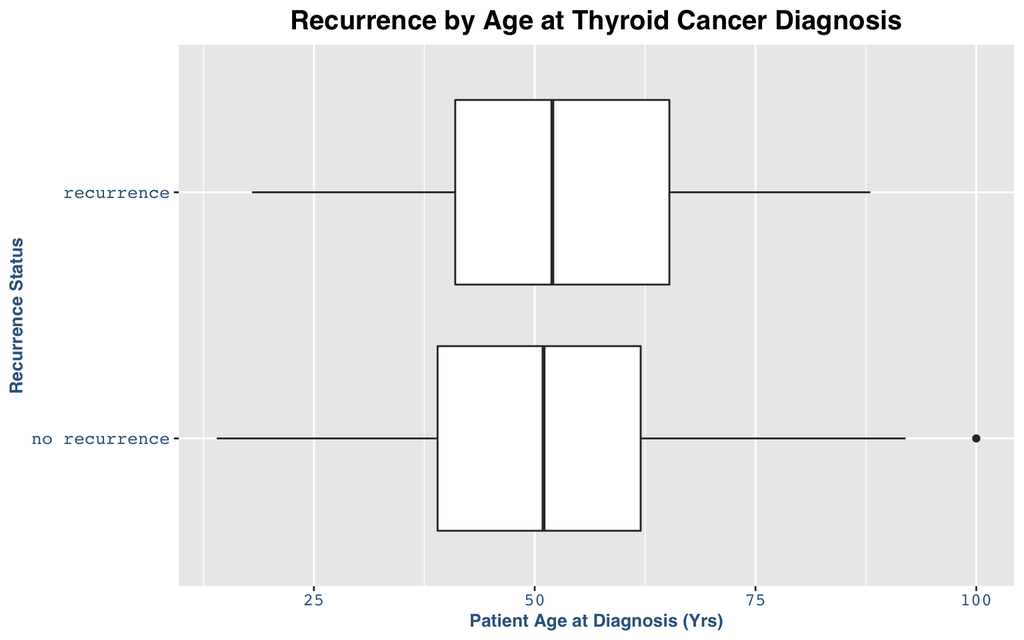

```r
    # Recurred (binary) as a function of patient age at diagnosis (continuous), with box plot

    recurred.age.plot <- ggplot(data = tumors3, aes(x = AgeAtDx.x, y = recurred)) +
      geom_boxplot() +
      ggtitle("Recurrence by Age at Thyroid Cancer Diagnosis") +
      mytheme + labs(y= "Recurrence Status", x="Patient Age at Diagnosis (Yrs)") +
     scale_fill_lancet()

    # Recurrence status (binary) as a function of sex (categorical), with bar plot
    recurred.sex.plot <- ggplot(data = tumors3, aes(x = factor(Sex), fill = recurred)) +
      geom_bar(position = "fill") +
      ggtitle("Recurrence Status by Sex") +
      mytheme + labs(y= "Percent Recurred", x="Sex") +
      scale_fill_lancet()

    # Recurrence status (binary) as a function of Lymphovascular Invasion (categorical), with bar plot
    recurred.LVI.plot <- ggplot(data = tumors3, aes(x = factor(LvInvasion), fill = recurred)) +
      geom_bar(position = "fill") +
      ggtitle("Recurrence Status by Lymphovascular Invasion") +
      mytheme + labs(y= "Percent Recurred", x="Lymphovascular Invasion Status") +
      scale_fill_lancet()

    # Recurrence status (binary) as a function of tumor upstaging (binary), with bar plot
    recurred.tupstaged.plot <- ggplot(data = tumors3, aes(x = factor(t.upstaged), fill = recurred)) +
      geom_bar(position = "fill") +
      ggtitle("Recurrence Status by Tumor Upstaging") +
      mytheme + labs(y= "Percent Recurred", x="Tumor Upstaging") +
      scale_fill_lancet()

    # Recurrence status (binary) as a function of clinical stage (categorical), with bar plot
    recurred.clinstage.plot <- ggplot(data = tumors3, aes(x = factor(ClinStage), fill = recurred)) +
      geom_bar(position = "fill") +
      ggtitle("Recurrence Status by Clinical Stage") +
      mytheme + labs(y= "Percent Recurred", x="Clinical Stage") + scale_fill_lancet()

    # Recurrence status (binary) as a function of pathologic stage (categorical), with bar plot
    recurred.pathstage.plot <- ggplot(data = tumors3, aes(x = factor(PathStage), fill = recurred)) +
      geom_bar(position = "fill") +
      ggtitle("Recurrence Status by Pathologic Stage") +
      mytheme + labs(y= "Percent Recurred", x="Pathologic Stage") + scale_fill_lancet()


    #Render the plots
    recurred.age.plot
```

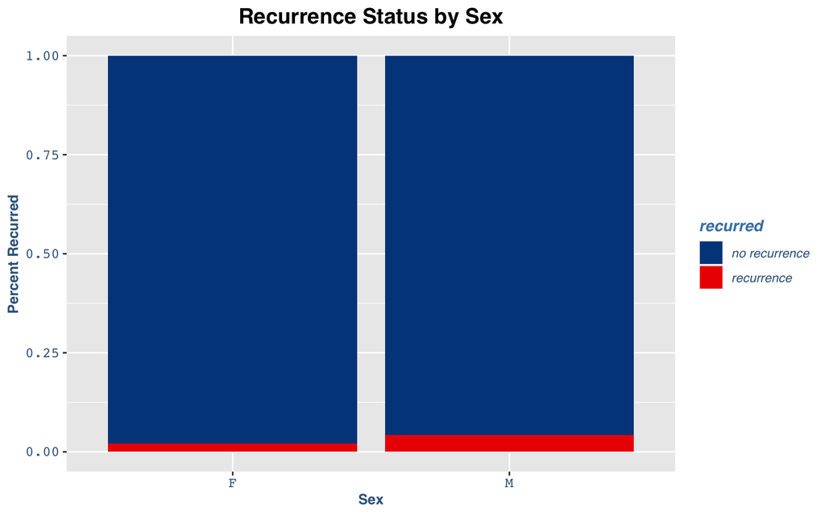

```r
    recurred.sex.plot
```

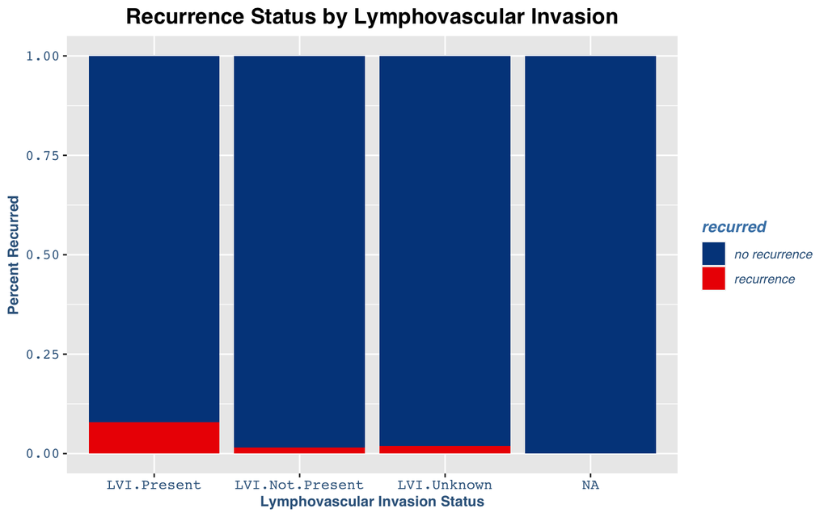

```r
    recurred.LVI.plot
```

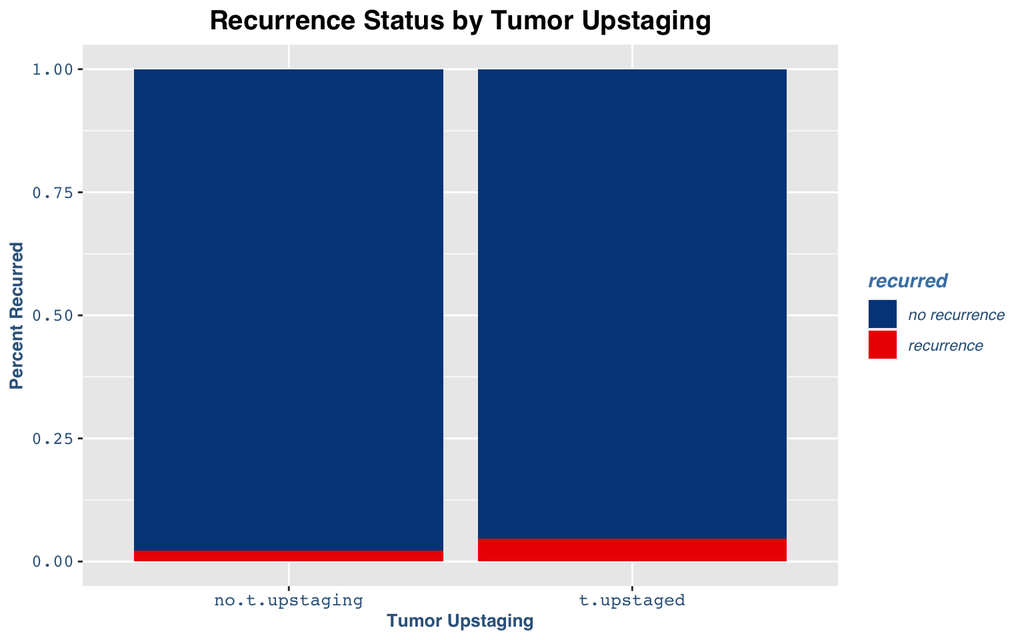

```r
    recurred.tupstaged.plot
```

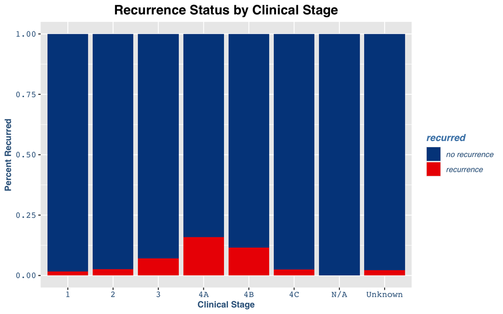

```r
    recurred.clinstage.plot
```

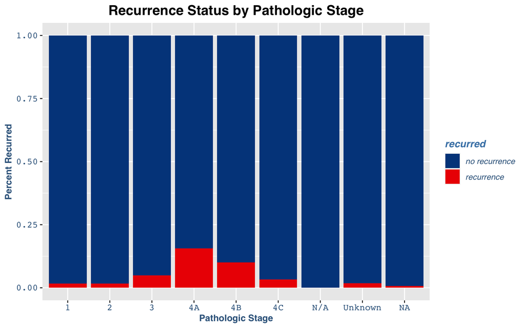

```r
    recurred.pathstage.plot
```

```r
    # Death status (binary) as a function of patient age at diagnosis (continuous), with box plot

    death.age.plot <- ggplot(data = tumors3, aes(x = AgeAtDx.x, y = death)) +
      geom_boxplot() +
      ggtitle("Death Status by Age at Thyroid Cancer Diagnosis") +
      mytheme + labs(y= "Death Status", x="Patient Age at Diagnosis (Yrs)")
    summary(glm(n.upstaged ~ AgeAtDx.x, data=tumors3, family = binomial()))
```

```
##
## Call:
## glm(formula = n.upstaged ~ AgeAtDx.x, family = binomial(), data = tumors3)
##
## Deviance Residuals:
##     Min       1Q   Median       3Q      Max
## -0.8167  -0.5476  -0.4504  -0.3690   2.5922
##
## Coefficients:
##              Estimate Std. Error z value Pr(>|z|)
## (Intercept) -0.479100   0.136813  -3.502 0.000462 ***
## AgeAtDx.x   -0.031968   0.002886 -11.075  < 2e-16 ***
## ---
## Signif. codes:  0 '***' 0.001 '**' 0.01 '*' 0.05 '.' 0.1 ' ' 1
##
## (Dispersion parameter for binomial family taken to be 1)
##
##     Null deviance: 3898.4  on 5350  degrees of freedom
## Residual deviance: 3769.4  on 5349  degrees of freedom
## AIC: 3773.4
##
## Number of Fisher Scoring iterations: 5
```

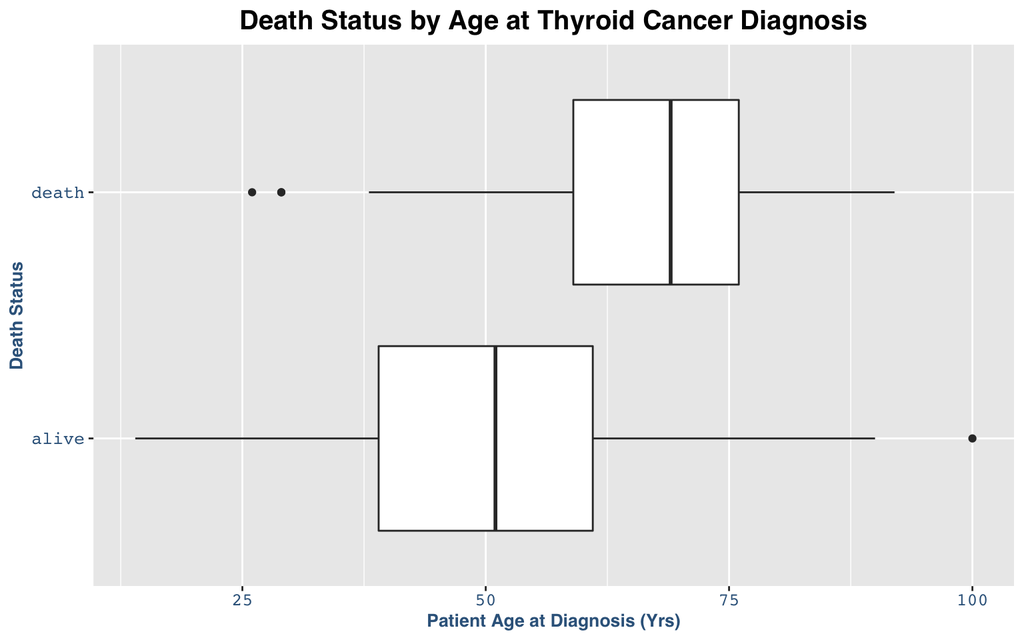

```r
    # Death status (binary) as a function of histology (categorical), with bar plot
    death.histology.plot <- ggplot(data = tumors3, aes(x = factor(HistologyDesc), fill = death)) +
      geom_bar(position = "fill") +
      ggtitle("Death Status by Tumor Histology") +
      mytheme + labs(y= "Death", x="Tumor HIstology") +
      scale_fill_lancet() + theme(axis.text.x = element_text(angle = 55,hjust=1))

    # Death status (binary) as a function of Clinical Stage (categorical), with bar plot
    death.clinstage.plot <- ggplot(data = tumors3, aes(x = factor(ClinStage), fill = death)) +
      geom_bar(position = "fill") +
      ggtitle("Death Status by Clinical Stage") +
      mytheme + labs(y= "Death", x="Clinical Stage") +
      scale_fill_lancet()

    #Render the plots
    death.age.plot
```

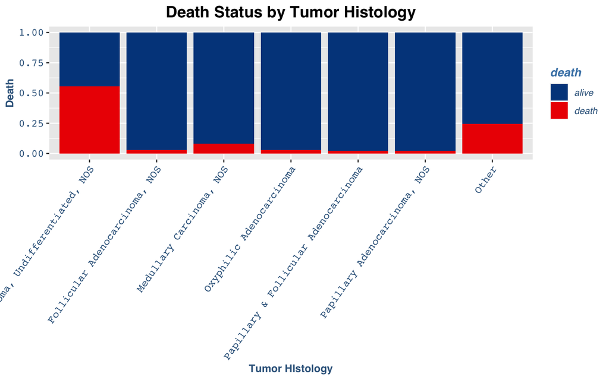

```r
    death.histology.plot
```

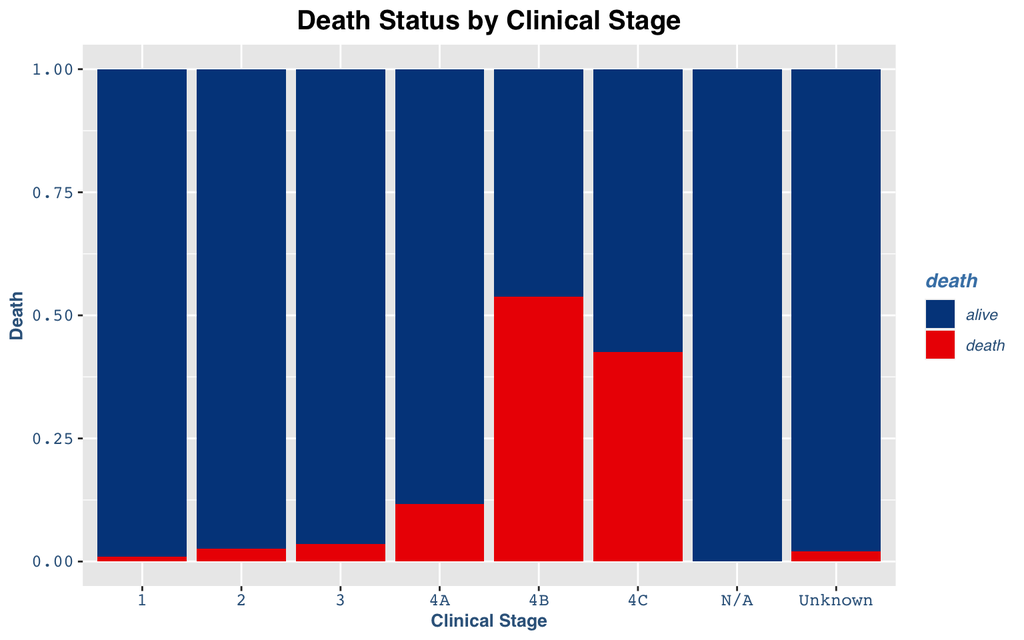

```r
    death.clinstage.plot
```

Further analyses with this dataset could include further exploration of the sequence of treatment modalities (encoded in the `FirstCourseSummary` variable) and analyses using the lag times between first contact and surgery. The variable `PrimarySequence` also encodes information about location where patients received their treatments and might warrant further exploration.

### References

1. Siegel RL, Miller KD, Jemal A. Cancer statistics, 2020. CA Cancer J Clin. 2020 Jan;70(1):7-30. doi: 10.3322/caac.21590. Epub 2020 Jan 8. PMID: 31912902.
2. Wells SA Jr, Asa SL, Dralle H, Elisei R, Evans DB, Gagel RF, Lee N, Machens A, Moley JF, Pacini F, Raue F, Frank-Raue K, Robinson B, Rosenthal MS, Santoro M, Schlumberger M, Shah M, Waguespack SG; American Thyroid Association Guidelines Task Force on Medullary Thyroid Carcinoma. Revised American Thyroid Association guidelines for the management of medullary thyroid carcinoma. Thyroid. 2015 Jun;25(6):567-610. doi: 10.1089/thy.2014.0335. PMID: 25810047; PMCID: PMC4490627.